# Batch correction: Simulation check

Kushal K Dey & Joyce Hsiao

September 24, 2015

```r
library(CountClust)
suppressMessages(library(mygene))
library(knitr)
suppressMessages(library(data.table))
suppressMessages(library(maptpx))
```

## Simulation model 1

Generate the counts $c_{ng}$ as

$c_{ng} \sim Poi \left (exp \left (\omega_{nk} \alpha_{kg} + \beta_{b(n):g} \right ) \right ) \hspace{1 in} \sum_{k} \omega_{nk} =1$

where $\omega_n$ represents the topic proportion vector for the $n$th sample, $\alpha_{kg}$ is the biological effect of the gene $g$ in cluster/topic $k$. $\beta_{b(n):g}$ is the gene $g$ specific batch effect of the $n$th sample.

```r
simulate_poisson_random_batch_1 = function(n_samples,
                                          n_genes,
                                          n_clus,
                                          topic_omega_sim,
                                          topic_alpha_sim,
                                          topic_beta_sim,
                                          label_batch_sim)
{

  # n_samples : the number of tissue or single cell samples
  # n_genes : the number of genes
  # n_clus: the number of topics/clusters
  # topic_omega_sim: omega (n_samples \times n_clus ) matrix of mixing proportions
  # topic_alpha_sim: alpha (n_clus \times n_genes) matrix of topic expressions
  # topic_beta_sim : beta (num_batches \times n_genes) matrix of batch effects
  # label_batch_sim: the labels of the batches startinf grom 1 to num_batches

  flag <- 0;
  if(n_clus !=dim(topic_omega_sim)[2]){
    print ("The number of clusters does not match with dimension of omega matrix");
    flag <- 1}
  if(n_clus !=dim(topic_alpha_sim)[1]){
    print ("The number of clusters does not match with dimension of alpha matrix");
    flag <- 1}
  if(max(label_batch_sim) !=dim(topic_beta_sim)[1]){
    print ("The number of batches does not match with the label vector");
    flag <- 1}
  if(flag==0) {
    out_temp=exp(topic_omega_sim%*%topic_alpha_sim +topic_beta_sim[label_batch_sim,]);
    out_temp_vec <- as.vector(out_temp);
    read_counts=matrix(unlist(lapply(1:length(out_temp_vec),function(x) rpois(1,out_temp_vec[x]))),nrow=n_samples);
    return(read_counts)}

}


N_sim = 500;
N_genes =1000;
N_clus =4;

alpha_true=matrix(rnorm(N_clus*N_genes,0.5,1),nrow=N_clus); ### the matrix of fixed effects

lab_batch=c(rep(1,N_sim/2),rep(2,N_sim/2));

B= max(lab_batch);

sigmab_true=2;

beta_true=matrix(0,B,N_genes);       ###  the matrix of the random effect

for(g in 1:N_genes)
{
  beta_true[,g]=rnorm(B,mean=0,sd=sigmab_true);
}

library(gtools)
T=N_sim/5;
omega_true=matrix(rbind(rdirichlet(T,c(3,4,2,6)),
                        rdirichlet(T,c(1,4,6,3)),
                        rdirichlet(T,c(4,1,2,2)),
                        rdirichlet(T,c(2,6,3,2)),
                        rdirichlet(T,c(3,3,5,4))), nrow=N_sim);


counts <- simulate_poisson_random_batch_1(N_sim, N_genes, N_clus, omega_true, alpha_true, beta_true, lab_batch)
```

### True structure plot

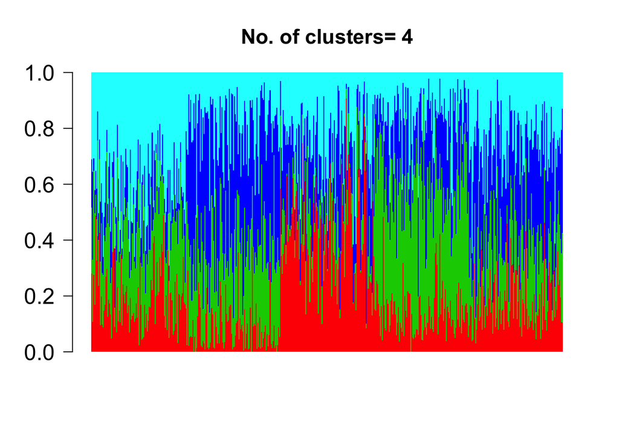

```r
barplot(t(omega_true),col=2:(N_clus+1),axisnames=F,space=0,border=NA,main=paste("No. of clusters=",N_clus),las=1,ylim=c(0,1),cex.axis=1.5,cex.main=1.4)
```

### Topic model fit (batch uncorrected)

```r
Topic_clus <- topics(counts,K=4, tol=0.5);
```

```
##
## Estimating on a 500 document collection.
## Fitting the 4 topic model.
## log posterior increase: 44464.2, 670.9, 503.5, 1662.2, 1865.6, 452.1, 181.1, 151.1, 314.6, 1347.9, 1323.5, 854.1, 283.3, 114.7, 28.6, 14.8, 8.9, 4.4, 2.2, 2, 3.9, 7.6, 6.6, 2.6, 1.3, 1.1, 1.1, 1.4, 1.9, 1.8, 1.1, 0.7, 0.5, done.
```

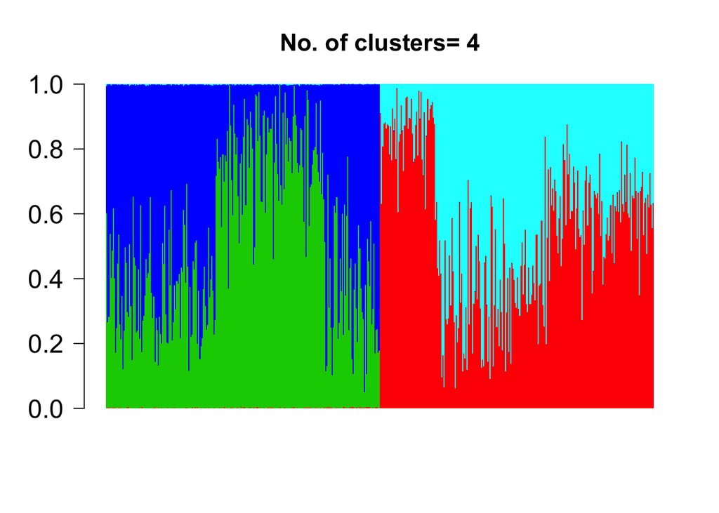

```r
docweights_topics=Topic_clus$omega;
barplot(t(docweights_topics),col=2:(N_clus+1),axisnames=F,space=0,border=NA,main=paste("No. of clusters=",N_clus),las=1,ylim=c(0,1),cex.axis=1.5,cex.main=1.4)
```

### Batch corrected Topic model fit

```r
batch_corrected_counts <- BatchCorrectedCounts(counts, lab_batch);

Topic_clus <- topics(batch_corrected_counts,K=4, tol=0.5);
```

[output not shown]

```r
docweights_topics=Topic_clus$omega;

library(permute);
library("BioPhysConnectoR");
```

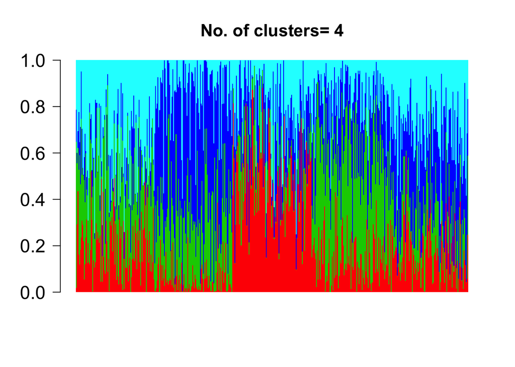

```r
perm_set=rbind(1:N_clus,allPerms(1:N_clus));
diff=array(0,dim(perm_set)[1]);
for (p in 1:dim(perm_set)[1])
{
  temp=docweights_topics[,perm_set[p,]];
  diff[p]=fnorm(temp,omega_true);
}

p_star=which(diff==min(diff));
docweights_topics=docweights_topics[,perm_set[p_star,]];


barplot(t(docweights_topics),col=2:(N_clus+1),axisnames=F,space=0,border=NA,main=paste("No. of clusters=",N_clus),las=1,ylim=c(0,1),cex.axis=1.5,cex.main=1.4)
```

We observe that the topic model fit on the batch corrected counts is pretty close to the original Structure plot. This sort of validates the fact that the batch correction scheme is working.

## Simulation model 2

Generate the counts $c_{ng}$ as

$c_{ng} \sim Poi \left ( \omega_{nk} exp \left (\alpha_{kg} + \beta_{b(n):g} \right) \right ) \hspace{1 in} \sum_{k} \omega_{nk} =1$

where $\omega_n$ represents the topic proportion vector for the $n$th sample, $\alpha_{kg}$ is the biological effect of the gene $g$ in cluster/topic $k$. $\beta_{b(n):g}$ is the gene $g$ specific batch effect of the $n$th sample.

```r
simulate_poisson_random_batch_2 = function(n_samples,
                                          n_genes,
                                          n_clus,
                                          topic_omega_sim,
                                          topic_alpha_sim,
                                          topic_beta_sim,
                                          label_batch_sim)
{

  # n_samples : the number of tissue or single cell samples
  # n_genes : the number of genes
  # n_clus: the number of topics/clusters
  # topic_omega_sim: omega (n_samples \times n_clus ) matrix of mixing proportions
  # topic_alpha_sim: alpha (n_clus \times n_genes) matrix of topic expressions
  # topic_beta_sim : beta (num_batches \times n_genes) matrix of batch effects
  # label_batch_sim: the labels of the batches startinf grom 1 to num_batches

  flag <- 0;
  if(n_clus !=dim(topic_omega_sim)[2]){
    print ("The number of clusters does not match with dimension of omega matrix");
    flag <- 1}
  if(n_clus !=dim(topic_alpha_sim)[1]){
    print ("The number of clusters does not match with dimension of alpha matrix");
    flag <- 1}
  if(max(label_batch_sim) !=dim(topic_beta_sim)[1]){
    print ("The number of batches does not match with the label vector");
    flag <- 1}
  if(flag==0) {
    out_temp <- matrix(0,nrow=n_samples, ncol=n_genes);
    for(n in 1:n_samples)
    {
      out_temp[n,] <- topic_omega_sim[n,]%*% exp(topic_alpha_sim + topic_beta_sim[label_batch_sim[n],]);
    }
    out_temp_vec <- as.vector(out_temp);
    read_counts=matrix(unlist(lapply(1:length(out_temp_vec),function(x) rpois(1,out_temp_vec[x]))),nrow=n_samples);
    return(read_counts)}

}


N_sim = 500;
N_genes =1000;
N_clus =4;

alpha_true=matrix(rnorm(N_clus*N_genes,0.5,1),nrow=N_clus); ### the matrix of fixed effects

lab_batch=c(rep(1,N_sim/2),rep(2,N_sim/2));

B= max(lab_batch);

sigmab_true=2;

beta_true=matrix(0,B,N_genes);       ###  the matrix of the random effect

for(g in 1:N_genes)
{
  beta_true[,g]=rnorm(B,mean=0,sd=sigmab_true);
}

library(gtools)
T=N_sim/5;
omega_true=matrix(rbind(rdirichlet(T,c(3,4,2,6)),
                        rdirichlet(T,c(1,4,6,3)),
                        rdirichlet(T,c(4,1,2,2)),
                        rdirichlet(T,c(2,6,3,2)),
                        rdirichlet(T,c(3,3,5,4))), nrow=N_sim);


counts <- simulate_poisson_random_batch_2(N_sim, N_genes, N_clus, omega_true, alpha_true, beta_true, lab_batch)
```

### True structure plot

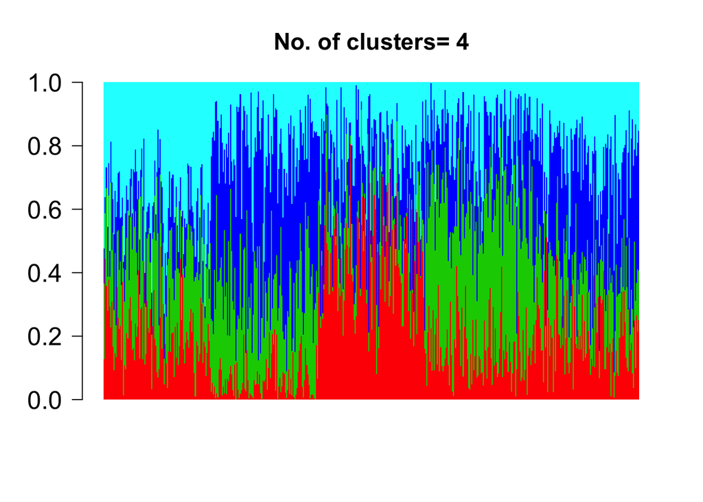

```r
barplot(t(omega_true),col=2:(N_clus+1),axisnames=F,space=0,border=NA,main=paste("No. of clusters=",N_clus),las=1,ylim=c(0,1),cex.axis=1.5,cex.main=1.4)
```

### Topic model fit (batch uncorrected)

```r
Topic_clus <- topics(counts,K=4, tol=0.5);
```

```
##
## Estimating on a 500 document collection.
## Fitting the 4 topic model.
## log posterior increase: 237051.3, 13825.9, 1009.8, 221.2, 81.1, 5.4, 2.7, 1.7, 1.1, 0.8, 0.5, done.
```

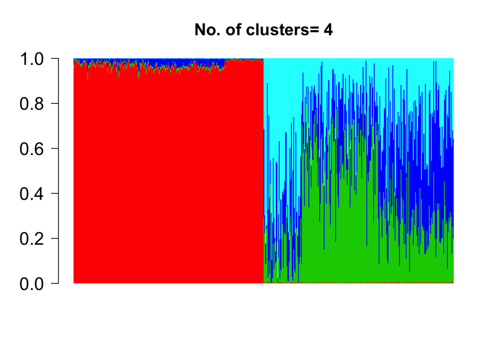

```r
docweights_topics=Topic_clus$omega;
barplot(t(docweights_topics),col=2:(N_clus+1),axisnames=F,space=0,border=NA,main=paste("No. of clusters=",N_clus),las=1,ylim=c(0,1),cex.axis=1.5,cex.main=1.4)
```

### Batch corrected Topic model fit

```r
batch_corrected_counts <- BatchCorrectedCounts(counts, lab_batch);

Topic_clus <- topics(batch_corrected_counts,K=4, tol=0.5);
```

[output not shown]

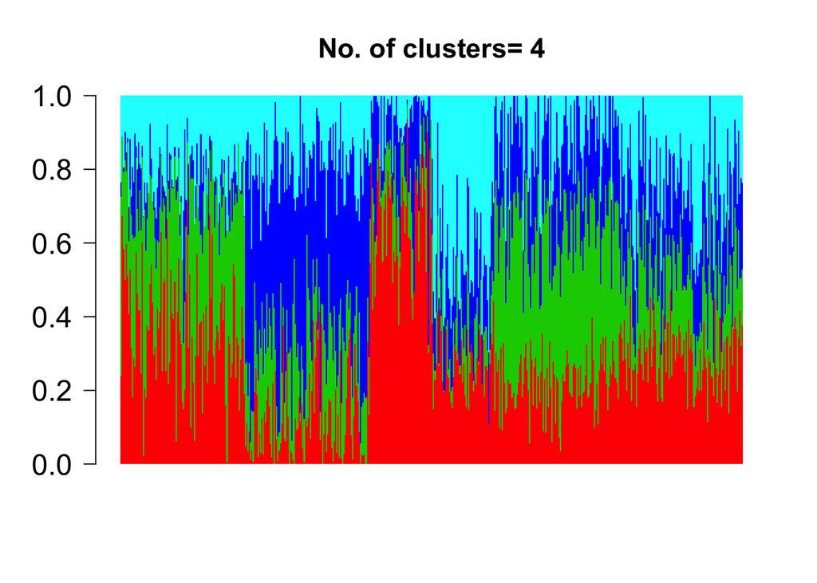

```r
docweights_topics=Topic_clus$omega;

library(permute);
library("BioPhysConnectoR");
perm_set=rbind(1:N_clus,allPerms(1:N_clus));
diff=array(0,dim(perm_set)[1]);
for (p in 1:dim(perm_set)[1])
{
  temp=docweights_topics[,perm_set[p,]];
  diff[p]=fnorm(temp,omega_true);
}

p_star=which(diff==min(diff));
docweights_topics=docweights_topics[,perm_set[p_star,]];


barplot(t(docweights_topics),col=2:(N_clus+1),axisnames=F,space=0,border=NA,main=paste("No. of clusters=",N_clus),las=1,ylim=c(0,1),cex.axis=1.5,cex.main=1.4)
```

## Simulation model 3

In this model, we assume the counts to be generated from the Multinomial model, a model that is similar to the topic model set up.

$c_{ng} \sim Mult (\sum_{k} \omega_{nk} \theta_{k, b(n),g})$

where

$\theta_{k, b(n), g} = \frac{ exp(\alpha_{kg} + \beta_{b(n):g})}{\sum_{g} exp(\alpha_{kg} + \beta_{b(n):g})}$

```r
simulate_poisson_random_batch_3 = function(n_samples,
                                          n_genes,
                                          n_clus,
                                          topic_omega_sim,
                                          topic_alpha_sim,
                                          topic_beta_sim,
                                          label_batch_sim)
{

  # n_samples : the number of tissue or single cell samples
  # n_genes : the number of genes
  # n_clus: the number of topics/clusters
  # topic_omega_sim: omega (n_samples \times n_clus ) matrix of mixing proportions
  # topic_alpha_sim: alpha (n_clus \times n_genes) matrix of topic expressions
  # topic_beta_sim : beta (num_batches \times n_genes) matrix of batch effects
  # label_batch_sim: the labels of the batches startinf grom 1 to num_batches

  flag <- 0;
  if(n_clus !=dim(topic_omega_sim)[2]){
    print ("The number of clusters does not match with dimension of omega matrix");
    flag <- 1}
  if(n_clus !=dim(topic_alpha_sim)[1]){
    print ("The number of clusters does not match with dimension of alpha matrix");
    flag <- 1}
  if(max(label_batch_sim) !=dim(topic_beta_sim)[1]){
    print ("The number of batches does not match with the label vector");
    flag <- 1}
  if(flag==0) {
    for(n in 1:n_samples)
    {
      effect <- exp(topic_alpha_sim +topic_beta_sim[label_batch_sim[n],]);
      effect <- apply(effect,2, function(x) x/sum(x));
      out_temp <- topic_omega_sim %*% effect;
    }

    read_counts=t(apply(out_temp,1, function(x) rmultinom(1,1000,prob=x)));
    return(read_counts)}

}


N_sim = 500;
N_genes =1000;
N_clus =4;

alpha_true=matrix(rnorm(N_clus*N_genes,0.5,1),nrow=N_clus); ### the matrix of fixed effects

lab_batch=c(rep(1,N_sim/2),rep(2,N_sim/2));

B= max(lab_batch);

sigmab_true=2;

beta_true=matrix(0,B,N_genes);       ###  the matrix of the random effect

for(g in 1:N_genes)
{
  beta_true[,g]=rnorm(B,mean=0,sd=sigmab_true);
}

library(gtools)
T=N_sim/5;
omega_true=matrix(rbind(rdirichlet(T,c(3,4,2,6)),
                        rdirichlet(T,c(1,4,6,3)),
                        rdirichlet(T,c(4,1,2,2)),
                        rdirichlet(T,c(2,6,3,2)),
                        rdirichlet(T,c(3,3,5,4))), nrow=N_sim);


counts <- simulate_poisson_random_batch_3(N_sim, N_genes, N_clus, omega_true, alpha_true, beta_true, lab_batch)
```

### True structure plot

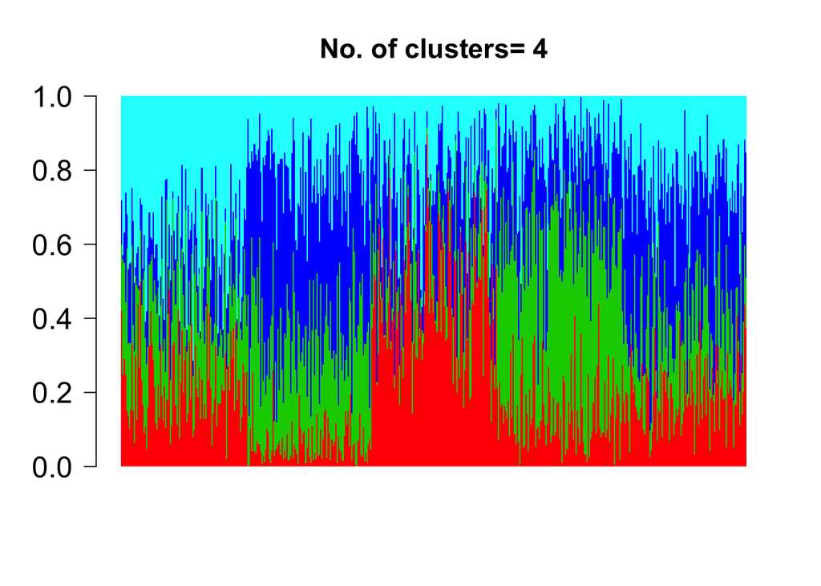

```r
barplot(t(omega_true),col=2:(N_clus+1),axisnames=F,space=0,border=NA,main=paste("No. of clusters=",N_clus),las=1,ylim=c(0,1),cex.axis=1.5,cex.main=1.4)
```

### Topic model fit (batch uncorrected)

```r
Topic_clus <- topics(counts,K=4, tol=0.5);
```

```
##
## Estimating on a 500 document collection.
## Fitting the 4 topic model.
## log posterior increase: 11469.3, 242.1, 97.6, 38.6, 22.7, 28.5, 48.7, 113.4, 241.1, 198.4, 256.9, 119.6, 44.3, 21, 13.3, 8.9, 5.6, 3.7, 2.9, 2.5, 2.3, 1.9, 1.6, 1.3, 1.1, 0.8, 0.7, 0.5, done.
```

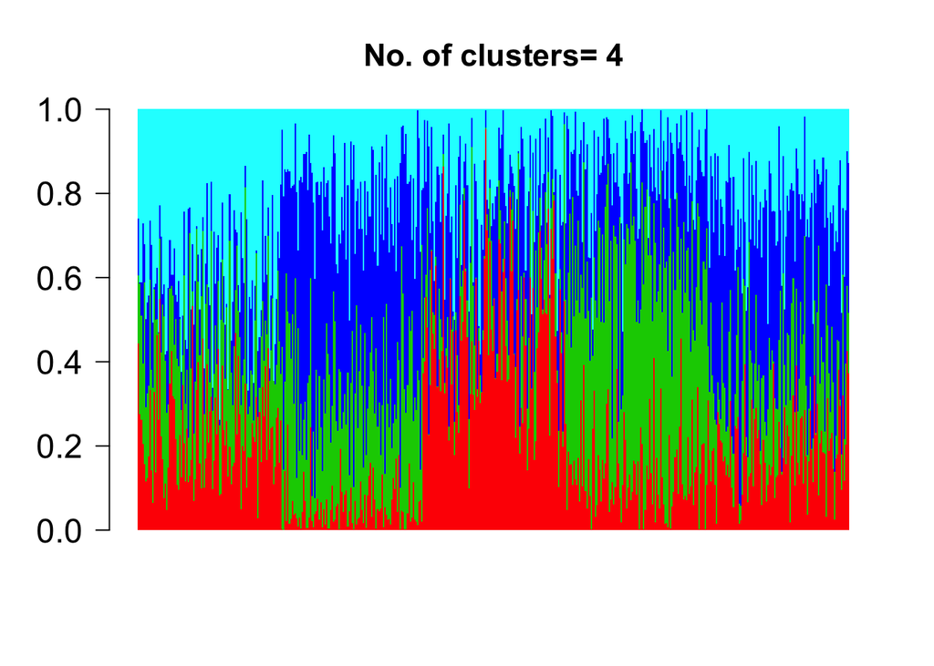

```r
docweights_topics=Topic_clus$omega;

library(permute);
library("BioPhysConnectoR");
perm_set=rbind(1:N_clus,allPerms(1:N_clus));
diff=array(0,dim(perm_set)[1]);
for (p in 1:dim(perm_set)[1])
{
  temp=docweights_topics[,perm_set[p,]];
  diff[p]=fnorm(temp,omega_true);
}

p_star=which(diff==min(diff));
docweights_topics=docweights_topics[,perm_set[p_star,]];


barplot(t(docweights_topics),col=2:(N_clus+1),axisnames=F,space=0,border=NA,main=paste("No. of clusters=",N_clus),las=1,ylim=c(0,1),cex.axis=1.5,cex.main=1.4)
```

### Batch corrected Topic model fit

```r
batch_corrected_counts <- BatchCorrectedCounts(counts, lab_batch);

Topic_clus <- topics(batch_corrected_counts,K=4, tol=0.5);
```

```
##
## Estimating on a 500 document collection.
## Fitting the 4 topic model.
## log posterior increase: 1721.4, 964.4, 188.3, 92.1, 52.1, 25.8, 15.2, 11.6, 10, 8.9, 8.2, 7.7, 7.8, 8.6, 10, 12, 14.7, 18.5, 24.1, 32.9, 48.7, 89.4, 170.3, 259.7, 140.9, 66, 36.4, 20.6, 12.9, 10, 8.3, 6.7, 5.2, 4.1, 3.6, 3.2, 2.8, 2.3, 1.9, 1.5, 1.3, 1.1, 0.9, 0.8, 0.7, 0.6, 0.6, 0.5, done.
```

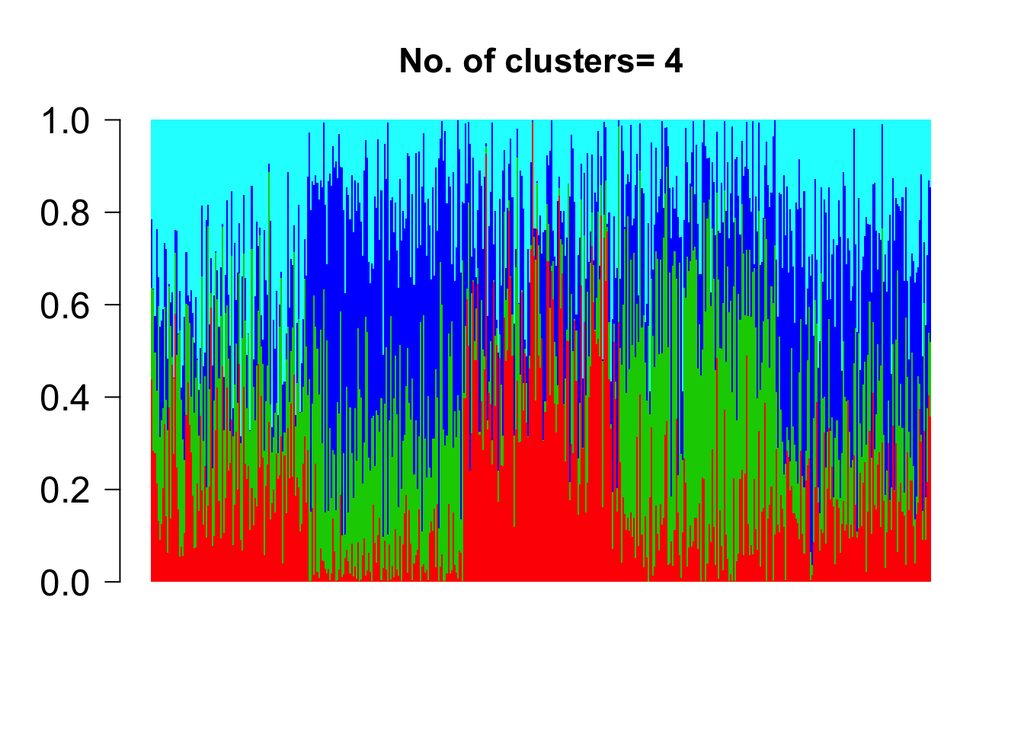

```r
docweights_topics=Topic_clus$omega;

library(permute);
library("BioPhysConnectoR");
perm_set=rbind(1:N_clus,allPerms(1:N_clus));
diff=array(0,dim(perm_set)[1]);
for (p in 1:dim(perm_set)[1])
{
  temp=docweights_topics[,perm_set[p,]];
  diff[p]=fnorm(temp,omega_true);
}

p_star=which(diff==min(diff));
docweights_topics=docweights_topics[,perm_set[p_star,]];


barplot(t(docweights_topics),col=2:(N_clus+1),axisnames=F,space=0,border=NA,main=paste("No. of clusters=",N_clus),las=1,ylim=c(0,1),cex.axis=1.5,cex.main=1.4)
```